# What Can Models Do? A Guide for Policy Practitioners

Joseph Mullins

## The Course So Far

- You’ve learned about evidence-based decision making
- You know why we need rigorous evidence: intuition and anecdotes aren’t enough
- You’ve seen how **randomized experiments** and **quasi-experiments** help us measure the effects of policies

**Today’s question:** What happens when the policy you’re considering *hasn’t been tried before*?

## What Experiments Tell Us

Experiments are the gold standard for answering:

> “What was the effect of *this specific policy* on *this specific population*?”

That’s incredibly valuable. But policymakers usually face a different question…

## What Policymakers Actually Need

> “What *would happen* if we implemented *this new policy* on *our population*?”
- The policy you’re designing may not match any past experiment exactly
- Your population may differ from the one that was studied
- You may want to compare several options that have never been tried
- You may wonder about the willingess to pay for certain policies

This is the gap that economic models fill.

# A Simple Example: The Market for Bananas

## Three Policies Under Consideration

The government is considering **three policies** to promote banana consumption:

Two questions:

- What does each policy do to the **price and quantity** of bananas?
- How much are consumers **willing to pay** for each one?

## One solution: run an Experiment

- Suppose we run an RCT for **Policy 1**:
  $$q_{m} = \beta_0 + \beta_1 Z_{m} + \epsilon_{m}$$
  $$p_{m} = \alpha_0 + \alpha_1 Z_{m} + \eta_{m}$$
  where $Z_{m}\in\{0,1\}$ indicates treatment and $(p,q)$ are (log) price and quantity.
- This gives us clean estimates of the % effect of subsidy on prices ($\alpha_1$) and quantities ($\beta_1$).
- But do $\alpha_1$ and $\beta_1$ tell us anything about **Policies 2 and 3**? Could we extrapolate with these results?

## Looking at the Data

Suppose we look at prices and quantities across all our markets.

[figure not shown]

Figure 1: Each dot is a market. No obvious relationship between price and quantity.

## Why Is It a Cloud?

Prices and quantities are **jointly determined** by supply and demand.

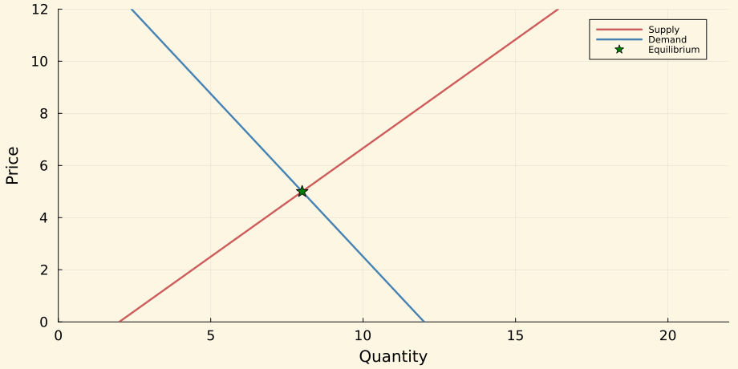

## Point 1

**Lesson**

Sometimes we need a model to make sense of the data and identify deep causal objects of interest.

## A Simple Theory

A simple economic model:

- **Consumers** choose how many bananas to buy: $\max_{Q} U(Q,X)$ subject to $PQ + X \leq Y$
- **Producers** choose how many to supply: $\max_{Q} PQ - C(Q)$ in a competitive market

The right $U$ and $C$ generate linear supply and demand across markets:

$$q_{m}^{D} = \kappa_0 - \kappa_1 p_{m} + \zeta_{m} \qquad \text{(demand)}$$
$$q_{m}^{S} = \gamma_0 + \gamma_1 p_{m} + \xi_{m} \qquad \text{(supply)}$$

where $\kappa_1$ and $\gamma_1$ are the **demand and supply elasticities** and $(\zeta_m, \xi_m)$ are unobserved shifters. The market clears: $q_m^D = q_m^S$.

- This generates the cloud we just saw
- The **elasticities** are the deep parameters — they govern how the market responds to *any* price change

## Using the Experiment to Identify the Model

The 10% demand subsidy shifts the demand curve. From the experimental estimates $\alpha_1$ and $\beta_1$, we can recover the structural elasticities.

[figure not shown]

Figure 3: The subsidy shifts demand. Comparing treatment and control traces out the supply response.

## Recovering the Deep Parameters

Recall: $\alpha_1$ is the effect of the consumer subsidy on log price; $\beta_1$ is the effect on log quantity.

**Producers** see a price change of $\alpha_1$, so the **supply elasticity** is:

$$\gamma_1 = \frac{\beta_1}{\alpha_1}$$

**Consumers** see a price change of $\alpha_1 + \log(0.9)$ (market price moved, *plus* the 10% subsidy), so the **demand elasticity** is:

$$\kappa_1 = -\frac{\beta_1}{\alpha_1 + \log(0.9)}$$

With $\gamma_1$ and $\kappa_1$, we can forecast the equilibrium effects of **any** price change — including policies we haven’t tested.

## Extrapolation and Interpolation

With the elasticities in hand, we can forecast **all three policies**:

|  | Policy 1 | Policy 2 | Policy 3 |
| --- | --- | --- | --- |
| **What it does** | 10% demand subsidy | 20% demand subsidy | 10% supply subsidy |
| **What shifts** | Demand | Demand | Supply |
| **Can we forecast?** | Directly estimated | Same curve, bigger shift | Different curve, already estimated |

- Policy 2 is an **extrapolation**: same type of shift, different magnitude
- Policy 3 shifts a *different curve* — the experiment alone tells us nothing about it, but the model connects them because both work through **known changes to prices**
- We can actually forecast the effects of all policies with *any* source of variation in supply and demand.

We call this *well-articulated variation*: when a policy’s effect can be traced through the model without needing new parameters.

## Point 2

**Lesson**

Economic models can jointly interpret many sources of variation for the purposes of policy and prediction.

## Revealed Preference and Welfare

- The experiment tells us quantities changed. But is the subsidy **worth what it costs**?
- In estimating the demand curve, we implicitly estimated consumers’ **utility** $U$ — how they value bananas relative to everything else.
- This is **revealed preference**: assuming people know what they like, their choices will reveal it to us
- We can calculate each consumer’s **willingness to pay** for the subsidy
- We can compare costs to government against benefits to consumers

This lets us evaluate policies without assuming we know what’s good for people better than they do.

## Point 3

**Lesson**

Economic models allow us to make welfare statements using **revealed preference**.

## Three Lessons from Bananas

1. **We needed the model to interpret the data.** Prices and quantities alone were a meaningless cloud. The theory of supply and demand identified the deep parameters that govern behavior.
2. **The model let us go beyond the experiment.** One experiment gave us enough to forecast three policies — including one on the supply side with no direct experimental analogue.
3. **The model let us measure welfare.** Not just “did quantities change?” but “are consumers better off, and by how much?”

Now let’s see this at work in a real policy setting.

# The General Idea

## Preferences, Constraints, and Policy

```
flowchart LR
    subgraph pref ["<b>Preferences</b>"]
        direction TB
        P1["How people rank<br>different outcomes"]
    end

    subgraph constraints ["<b>Constraints</b>"]
        direction TB
        C1["Available choices given<br>prices and endowments"]
    end

    G["<b>Government policy</b><br>Taxes, subsidies,<br>transfers, regulations"]

    pref --> D(("<b>Decision</b><br>Maximize preferences<br>subject to constraints"))
    constraints --> D
    G --> |"changes prices<br>and endowments"| constraints

    style P1 fill:#268bd2,color:#fff,stroke:none
    style C1 fill:#6c71c4,color:#fff,stroke:none
    style D fill:#b58900,color:#fff,stroke:none
    style G fill:#dc322f,color:#fff,stroke:none
    style pref fill:none,stroke:#268bd2,stroke-width:2px
    style constraints fill:none,stroke:#6c71c4,stroke-width:2px
```

- In the banana example: **preferences** = consumer utility $U$; **constraints** = prices and income; **policy** = the subsidy, which changes prices
- Models are especially powerful when policies work through **known changes to prices and endowments** — *well-articulated variation*

## Applying This to Welfare Policy

```
flowchart LR
    subgraph pref ["<b>Preferences</b>"]
        direction TB
        P1["Value of consumption<br>vs. leisure"]
        P2["Value of time<br>with children"]
        P3["Cost of working<br>and childcare"]
    end

    subgraph constraints ["<b>Budget constraint</b>"]
        direction TB
        W["<b>Wages</b><br>Job opportunities"]
        R["<b>Policy rules</b><br>Transfers, phase-outs,<br>work requirements"]
    end

    pref --> D(("<b>Decision</b><br>Work? How much?<br>Participate?"))
    constraints --> D
    D --> H["<b>Outcomes</b><br>Earnings, consumption,<br>child development"]

    style P1 fill:#268bd2,color:#fff,stroke:none
    style P2 fill:#268bd2,color:#fff,stroke:none
    style P3 fill:#268bd2,color:#fff,stroke:none
    style W fill:#6c71c4,color:#fff,stroke:none
    style R fill:#dc322f,color:#fff,stroke:none
    style D fill:#b58900,color:#fff,stroke:none
    style H fill:#859900,color:#fff,stroke:none
    style pref fill:none,stroke:#268bd2,stroke-width:2px
    style constraints fill:none,stroke:#6c71c4,stroke-width:2px
```

- Individuals choose how much to **work** and whether to **participate** based on their preferences, given policy rules and labor market opportunities
- Welfare policies give **transfers** (endowments) and shape the **returns to work** (prices) — well-articulated variation

# Welfare Reform: The Application

## The Setting

In the 1990s, the US overhauled its welfare system.

- Before the national reform, **different states ran different experiments**
- Each tested a different bundle of rules:
  - Work requirements
  - Time limits on benefits
  - Earnings disregards (how much you can earn before losing benefits)

Each experiment was well-designed and carefully evaluated.

## What Each Experiment Told Us

Each experiment answered a narrow question:

> “This bundle of rules, applied to this population, had these effects on employment, earnings, and child outcomes.”

For example:

- Minnesota’s MFIP: generous earnings disregard + mandatory services
- Connecticut’s Jobs First: strict time limits + generous earnings disregard
- Florida’s FTP: time limits + modest earnings disregard

Each experiment is like testing **one subsidy** in **one market**.

## The Policymaker’s Problem

You’re a state official designing a new welfare program.

- None of these experiments match your proposed rules exactly
- Your state’s population differs from Minnesota’s or Connecticut’s
- You want to know about a **specific combination** of rules

Just as with bananas: the experiment on *one* policy doesn’t directly tell you about a *different* policy on a *different* population.

## What the Model Does

The same logic as the banana example, applied to a richer setting:

- Each welfare experiment **shifts the budget constraint** in a known way
- Fitting a model to *all* the experiments simultaneously recovers the **deep parameters**: how people trade off income, leisure, time with children, and the costs of working
- With those parameters, we can forecast the effects of *any* new combination of rules

Different experiments provide different information (just like the demand and supply subsidies) and the model connects them through a common framework.

## An Example From My Research

In Mullins (2026), I did exactly this:

- Took data from **multiple welfare reform experiments** across US states
- Estimated a model of maternal labor supply and children’s development
- Used it to evaluate new policy designs

Key finding: across sites, time limits were primarily responsible for reductions in welfare dependence, while work requirements were the chief source of employment gains.

**That insight was impossible to get from the experiments alone.**

## Where Models Reach Their Limits

Not every policy fits this framework.

- If a policy works through a **channel the model doesn’t represent** — social norms, information, neighborhood effects — you can’t just plug it in
- You’d need to extend the model or build a different one
- A key requirement is that the variation you want to study is well-articulated inside the model.

Part of the economist’s job is knowing which questions a given model can and can’t handle.

# How Do We Know the Model Is Right?

## A Fair Question

You might be thinking:

> “This sounds like you’re just making assumptions and running with them.”

That’s a fair concern. Here are some points to keep in mind…

## Models Are Disciplined by Data

- Models are **estimated**, not assumed — parameters are chosen to match real data
- They can be **tested** against evidence not used in estimation: estimate on some experiments, check predictions against others
  - In my welfare reform paper, the model was estimated on a subset of experiments and validated against the rest.

## Models Are Transparent About Assumptions

- Every model involves assumptions — but so does every research design
- Assumptions are **written down explicitly**
- You can ask: “What if this assumption is wrong? How much does it matter?”
- A model lets you be explicit about how you are getting from existing evidence to a conclusion about future policies.
- This is more transparent than informal reasoning, where assumptions are implicit.
- Especially important when policy goal is to improve welfare. How do we know this is what people prefer?

## Recap

1. **Models help interpret data**: without structure, even simple data can be impossible to read
2. **Models extrapolate and interpolate**: especially when policies work through known changes to prices and endowments
3. **Models enable welfare calculations**: not just “what changed?” but “are people better off?”
4. **Models are disciplined by data**: estimated, testable, and transparent (if done well)

## Thank You

Questions?

## References

Mullins, Joseph. 2026. “A Structural Meta-Analysis of Welfare Reform Experiments and Their Impacts on Children.” *Journal of Political Economy* 134 (1): 435–77. https://doi.org/10.1086/738482.